# Aula 1 - Números Complexos

# Professor: Carlan

[figure not shown]

## Números Complexos Historicamente:

[figure not shown]

> Os números complexos foram desenvolvidos a partir do século XVI por um matemático Italiano chamado Gerolamo Cardano. Cardano buscava conceber uma solução numérica para equações do tipo $x^2 + 1 = 0$. Posteriormente, outro matemático Italiano, Niccolò Fontana Tartaglia, contribuiu para o desenvolvimento da teoria aplicando para a solução de equações do terceiro grau. A teoria também foi amplamente utilizada e desenvolvida por grandes nomes da matemática como Gauss e Euler, que aplicaram os complexos em abordagens mais geométricas.

## Definição:

### Primeiros Passos:

> O surgimento dos números complexos vem da equação do segundo grau:

> $$x^2 + 1 = 0 \longrightarrow x^2 = -1 \longrightarrow x = \pm \sqrt{-1} $$

> Onde definimos a UNIDADE IMAGINÁRIA (i), tal que:

> $$ i = \sqrt{-1} \ onde \ i^2 = -1$$

> Por se tratar de uma equação do segundo grau, é esperado que ela possua DUAS soluções, por isso as raízes da equação $x^2 + 1 = 0$ são $x_1 = i \ e \ x_2 = -i$.

> Porém, já foi visto que é possível que a raíz de uma equação do segundo grau não seja apenas composta de um termo múltiplo de i.

### Definição Geral:

> Tomemos agora como exemplo a seguinte equação do segundo grau:

> $$ x^2 +4x + 6= 0$$

> A resolução da equação nos leva até :

> $$x = \frac{-4 \pm \sqrt{-8}}{2} \longrightarrow x = \frac{-4 \pm \sqrt{-2}\sqrt{4}}{2} \longrightarrow x = \frac{-4 \pm 2\sqrt{-2}}{2}\longrightarrow x = -2 \pm \sqrt{-2}$$

> Com isso percebemos que os números complexos não precisam ser inteiramente de um múltiplo de i. Por definição, um número complexo é aquele, geralmente denotado por z, que pode ser escrito da forma

[figure not shown]

> Onde a representa a PARTE OU COMPONENTE REAL, b representa a PARTE OU COMPONENTE IMAGINÁRIA. Importante ressaltar que tanto a quanto b são números REAIS, o único responsável pela classificação de z como complexo é o termo imaginário i. Dessa forma as raízes da equação anterior podem ser representadas como:

> $$ a= -2 \ e \ b = \pm \sqrt{2} \longrightarrow x = -2 \pm \sqrt{2} \ i $$

### Conceitos importantes:

#### Conjunto dos números complexos:

[figure not shown]

#### Imaginário puro: $ Re(z) = a = 0 \longrightarrow z = bi$

#### Conjugado de um número complexo:

> > O conjugado apresenta a mesma parte real e a parte imaginária com sinal contrário: $\bar{z} = a - bi$

> > Importante o caso da conjugação dupla: $\bar{\bar{z}} = \overline{(a - bi)} = a + bi = z$

### Algumas Operações com Números Complexos:

#### Igualdade de dois complexos:

> > $z_1 = z_2 \longrightarrow a + bi = c + di$

> > a = c

> > b = d

#### Soma/Subtração de dois complexos:

> > $z_1 + z_2 = (a + bi)+ (c + di) = (a + c) + (b + d) i$

> > $z_1 - z_2 = (a + bi)- (c + di) = (a - c) + (b - d) i$

> > **Casos importantes:**

> > $z + \overline{z} = a + bi + (a - bi) = 2a \longrightarrow z + \overline{z} = 2 Re(z)$

> > $z - \overline{z} = a + bi - (a - bi) = 2bi \longrightarrow z - \overline{z} = 2i Im(z)$

#### Produto de números complexos:

> > $z_1.z_2 = (a + bi)(c + di) = ac + adi + bci + bdi^2 = (ac - bd) + (ad + bc)i$

> > **Usando o conjugado** $z\overline{z} = (a + bi)(a - bi) = a^2 - (bi)^2 = a^2 - b^2i^2 = a^2 + b^2 = Re(z)^2 + Im(z)^2$

#### Divisão de números complexos:

> > Aqui, podemos fazer um processo semelhante a uma "racionalização" do denominador, onde usamos um produto do mesmo número tanto no numerador quanto no denominador para que o número resultante no denominador tenha parte imaginária **NULA**.

> > $$\frac{z_1}{z_2} = \frac{z_1}{z_2}\times \frac{\overline{z_2}}{\overline{z_2}} = \frac{z_1\overline{z_2}}{z_2\overline{z_2}} = \frac{z_1\overline{z_2}}{Re(z_2)^2 + Im(z_2)^2} $$

## Vamos Praticar:

**1 - Resolva as seguintes operações:**

a) (5 +3i) + (8 + 5i) =

b) (7 + 2i)(4 - 3i) =

c) (6 + 7i) - (4 + 2i) + (1 - 10i) =

d) (5 + 4i)(1 - i) + (2 + i)i =

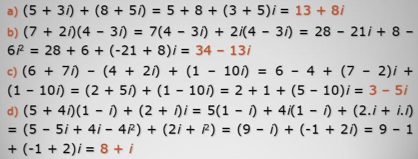

**2- Quais dos seguintes números são números complexos?**

a) 2i - 7 sim

b) (i + 3)² = i² +6i + 9 = 8 + 6i sim

c) 4 - (3i)i = 4 - 3i² = 4 + 3 = 7 sim, porém sem parte imaginária

**3 - Descubra os valores das constantes (a e b) usando propriedades de números complexos:**

a) a + bi = 7i - 9

b) 14 - bi = a + 3i

c) 23i = a - bi

d) a = bi

**4- Calcule as seguinte potências:**

a) $i^0$

b)$i^1$

c) $i^2 $

d) $i^3 $

e) $i^4 $

f) $i^5 $

g) $i^6 $

h)$i^7 $

i) $i^8 $

**6- Calcule as seguinte potências:**

a)$ i^{27}$

b)$i^{43}$

c)$i^{100}$

d)$i^{1147}$

**7- Calcule as seguinte potências:**

a)$ i^{-1}$

b)$i^{-16}$

c)$i^{-77}$

d)$i^{-1413}$

# Aula 2 - Números Complexos

## Abordagem Geométrica dos Números complexos

### O Plano de Argand-Gauss

> > Jean-Robert Argand teve a ideia de abordar os números complexos como um conjunto de duas coordenadas, onde a coordenada no eixo das abcissas seria o valor da parte de real e a coordenada do eixo das ordenadas seria a parte imaginária. Dessa forma seria possível interpretar os números complexos como vetores num plano bidimensional. Posteriormente, outro matemático chamado H. F. Gauss descobriu uma série de propriedades dessa definição.

[figure not shown]

> > **Aqui, a e b são normalmente referidos como AFIXOS.**

### Conceitos Geométricos:

> > **Módulo do Número Complexo** ($\rho$ ou |z|): É a distância entre a origem e o ponto de coordenadas (a,b), ou o comprimento do vetor que representa o número complexo:

> > $\rho$ = |z| = $\sqrt{a^2 + b^2}$

> > **Argumento de um Número Complexo** ( $\theta$ ) : É o ângulo que o vetor que representa o número complexo faz com o eixo das abcissas, partindo sempre da orientação **x positivo** e rotacionando no sentido **anti-horário**.

[figure not shown]

> > **Parte Real e Parte Imaginária de acordo com |Z| e** $\theta$: Com os valores do módulo e do argumento de Z é possível descobrir Re(Z) e Im(Z) usando relações trigonométricas:

[figure not shown]

> > $$sen(\theta) = \frac{Cateto \ Oposto}{Hipotenusa} \longrightarrow \ sen(\theta) = \frac{b}{|z|} \longrightarrow \ b = |z| sen(\theta)$$$$cos(\theta) = \frac{Cateto \ Adjacente}{Hipotenusa} \longrightarrow \ cos(\theta) = \frac{a}{|z|} \longrightarrow \ a = |z| cos(\theta)$$

> > O que faz sentido já que é sabido da trigonometria que:

> > $$sen(\theta)^2 + cos(\theta)^2 = 1 \rightarrow (multiplicando \ por \ |z|^2) \rightarrow (|z|sen(\theta))^2 + (|z|cos(\theta))^2 = |z|^2 \longrightarrow |z|^2 = a^2 + b^2$$

> > **Números Complexos na notação CIS:** Substituindo a e b por equivalentes trigonométricos, podemos caracterizar um complexo z da seguinte forma:

> > $$z = a + bi \Rightarrow z = |z|cos(\theta) + |z|sen(\theta)i \Rightarrow z = |z|(cos(\theta) + isen(\theta))$$

> > A parte $(\underline{c}os(\theta) + \underline{is}en(\theta))$ pode ser escrita da forma simplificada $cis(\theta)$.

> > Assim temos as duas representações possíveis

> > $$z = a +bi$$

> > $$z=|z|cis(\theta)$$

> > **O conjugado na forma geométrica**: Sabemos que o conjugado de um complexo z= a + bi é dado por $\overline{z} = a - bi$, pelo círculo trigonométrico, temos que:

[figure not shown]

> > $$\begin{cases} cos(-\theta) = cos(\theta) \\ sen(-\theta) = -sen(\theta) \end{cases}$$

> > Logo, para o conjugado temos a seguinte propriedade:

> > $$\overline{z} = a - bi = |z|(cos(\theta) - isen(\theta)) = |z|[cos(-\theta) - (-isen(-\theta))]$$$$\overline{z} = |z|(cos(-\theta) + isen(-\theta)) \Longrightarrow \overline{z} = |z|cis(-\theta)$$

[figure not shown]

### Exercícios:

1) Escreva os números complexos do plano na forma algébrica e calcule o módulo de cada um deles: Lembrando: $|Z| = \sqrt{a^2 + b^2}$

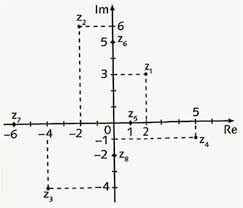

$z_1$ = 2 + 3i $\longrightarrow$ $|z|=\sqrt{13}$

$z_2$ = -2 + 6i $\longrightarrow$ $|z|=\sqrt{40}$

$z_3$ = -4 -4i $\longrightarrow$ $|z|=\sqrt{32}$

$z_4$ = 5 - i $\longrightarrow$ $|z|=\sqrt{26}$

$z_5 $= 1 $\longrightarrow$ $|z|= 1$

$z_6 $= 5i $\longrightarrow$ $|z|= 5$

$z_7$ = -6 $\longrightarrow$ $|z|= 6$

$z_8$ = -2i $\longrightarrow$ $|z|= 2$

2) Passe os seguintes números complexos da forma trigonométrica para a forma algébrica:

$z = 10cis(45)$

//

$z = 8cis(120)$

//

$z = 9cis(\pi)$

//

$z = 12cis(-60)$

//

$z = 3cis(\frac{3\pi}{2})$

3) Converta os seguintes números complexos da forma algébrica para a trigonométrica, diga o valor do módulo e do argumento de cada um deles:

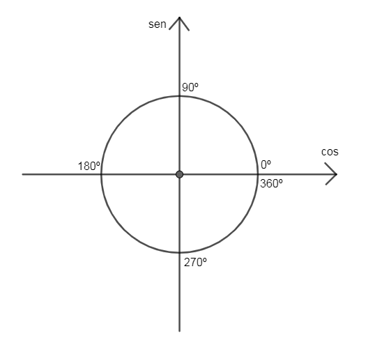

$z = 4\sqrt{3} + 4i$

\

$z = - 5 - 5i$

\

$ z = -8 i$

\

$z = -3 + 3\sqrt{3}i$

\

$ z = 14 i $

# Aula 3: Números Complexos

## As Relações de Moivre

### Produto de dois números complexos na forma trigonométrica:

> > Tomemos como base o produto de dois complexos z_1 e z_2 para ver o surgimento de uma relação trigonométrica interessante:

> > $$\begin{cases} z_1 = |z_1|(cos(\theta) + isen(\theta)) \\ \\ z_2 = |z_1|(cos(\alpha) + isen(\alpha)) \\ \\z_1z_2 = |z_1|(cos(\theta) + isen(\theta))|z_2|(cos(\alpha) + i(sen(\alpha)) \end{cases}$$

> > \

> > $$z_1z_2 = |z_1||z_2|[ (cos(\theta)cos(\alpha) - sen(\theta)sen(\alpha)) + i(cos(\theta)sen(\alpha) + cos(\alpha)sen(\theta))]$$

> > Da trigonometria, sabemos as relações de soma de arco em funções trigonométricas:

> > $$\begin{cases} cos(\theta + \alpha) = cos(\theta)cos(\alpha) - sen(\theta)sen(\alpha) \\ \\ sen(\theta + \alpha) = cos(\theta)sen(\alpha) + cos(\alpha)sen(\theta) \end{cases}$$

> > O que resume o produto de dois números complexos na forma trigonométrica como:

> > $$ z_1z_2 = |z_1||z_2| cis(\theta + \alpha)$$

> > Em outras palavras, na forma trigonométrica, o produto de dois números complexos resulta em um complexo cujo módulo é dado pelo produto dos módulos e o argumento dado pela soma dos argumentos.

> > Baseado nisso foi derivada a primeira relação de Moivre, fazendo o produto de n complexos iguais:

> > $$z \times z \times z ... \times z = z^n \longrightarrow z = |z|cis(\theta)$$$$z^n = |z|cis(\theta) \times |z|cis(\theta) \times |z|cis(\theta) \times |z|cis(\theta)...|z|cis(\theta) \times |z|cis(\theta)$$

> > \

> > $$ z^n = |z|^n cis(n\theta)$$

### Divisão de dois complexos na forma trigonométrica:

> > Podemos fazer o procedimento análogo para a divisão de dois complexos z_1 e z_2:

> > $$ \frac{z_1}{z_2} = \frac{|z_1|}{|z_2|} \frac{cis(\theta)}{cis(\alpha)}$$

> > Se multiplicarmos a equação da direita por $\frac{cis(-\alpha)}{cis(-\alpha)}$, onde $cis(-\alpha)$ é o conjugado de $cis(\alpha)$ teremos:

> > $$ \frac{z_1}{z_2} = \frac{|z_1|}{|z_2|} \frac{cis(\theta)}{cis(\alpha)}\frac{cis(-\alpha)}{cis(-\alpha)} = \frac{|z_1|}{|z_2|}\frac{cis(\theta + (-\alpha))}{cis(\alpha- \alpha)} \longrightarrow \frac{z_1}{z_2} = \frac{|z_1|}{|z_2|} cis(\theta - \alpha) $$

> > Em outras palavras, a divisão de dois complexos resulta em um complexo cujo módulo é a razão dos módulos dos complexos e o argumento é dado pela diferença entre os argumentos.

> > **TENTEM LEMBRAR PELO PRODUTO E DIVISÃO DE POTÊNCIAS**

**Exercícios**

1) calcule o valor das seguintes potências de números complexos:

a) $z=\sqrt{2} + \sqrt{2}i \longrightarrow z^8?$

\

b) $z = i \longrightarrow z^{11}?$

\

c) $z = 3 + 3\sqrt{3}i \longrightarrow z^6? $

\

2) Diga qual o argumento dos seguintes produtos:

a) i.i.i.i.i.i

\

b)$ \frac{cis(30)cis(\pi/4)}{cis{20}^3} $

\

c)$cis(40)^9 \overline{cis(20)}^{18}$

# Aula 4: Números Complexos

## Encontrando Raízes Complexas em Equações:

### Radiciação de Números complexos:

> >

> > Poderíamos usar o mesmo raciocínio da Potenciação de números complexos, chegando no seguinte resultado:

> > $$ z^{1/n} = |z|^{1/n} cis(\frac{\theta}{n})$$

> > Porém, tal resultado não é o único possível que satisfaz a radiciação. Para entender o porquê podemos pensar na solução de equações, por exemplo:

> > $$x^2 = 4$$

> > Nesse caso, há duas possíveis raízes que satisfazem a equação, $x_1 = +2 \ e\ \ x_2 = -2$, onde na forma complexa trigonométrica seria:

> > $ \begin{cases} x_1 = 2 = 2cis(0) \rightarrow 2 = \sqrt{4}cis(\frac{0}{2}) \\ \\ \\ x_2 = -2 = 2cis(\pi) \rightarrow -2 = \sqrt{4}cis(\frac{0}{2} +\frac{2\pi}{2} ) \end{cases}$

> > Como é esperado, a segunda raíz elevada a segunda potência também resulta em 4.

> > Isso ocorre porque, geometricamente, os ângulos possuem múltiplos com mesma localização no plano.

> > $ 2 \times 0° = 2 \times ( 0° + 180°)$

> > Usemos agora um exemplo de maior ordem: $ x^3 = 8$. Por ser do terceiro grau, é necessário achar um total de três raízes para a equação.

> > 1ª: $x_1= \sqrt[3]{8} = 2$

> > 2ª e 3ª, partiremos do caso geral $x = \sqrt[3]{8} cis(\theta)$

> > $x^3 = 8 \times cis(3\theta) = 8 = 8cis(0°)$

> > 0° (primeira volta) já foi utilizado na primeira raíz, vamos usar os equivalentes 360° e 720°:

> > $\theta_1 = 360/3 = 120°$ e $\theta_2 = 720/3 = 240°$ Logo as possíveis raízes são : x=2 , x = 2cis(120°) e x= 2cis(240°).

> > Ou na forma algébrica: x = 2, $x = -1 + i \sqrt{3}$ e $x = -1 - i\sqrt{3}$

> > Podemos ver que os afixos das raízes são rotacionados entre si de um ângulo igual a 360°/3 = 120°, e a figura formada no plano de Argand Gauss é um triângulo equilátero:

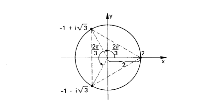

### Caso geral:

> > $$\sqrt[n]{z} = z_k \rightarrow z_k = |z_k| cis\Big( \frac{\theta}{n} + k \times \frac{2\pi}{n}\Big) \ \ \ , \ \ k = 0,1,2,...n-1$$

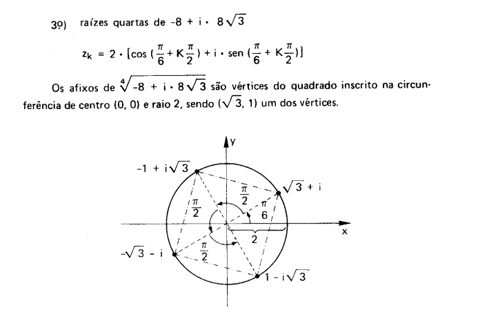

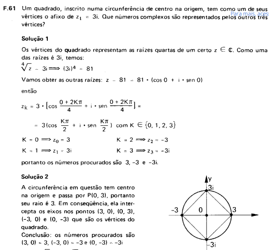

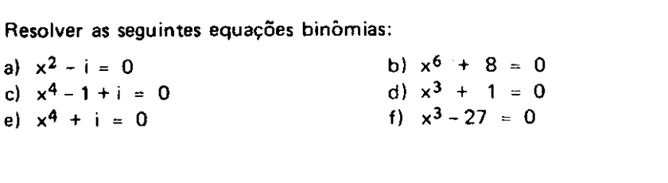